# VIN SAMPLE DATA

Riley Zamora

2023-09-25

# Libraries

```r
library(ggplot2)
library(tidyverse)
```

# Abstract

In this short analysis, I will be looking at some sample vehicle data with the goal of finding anything useful.

# Load and Inspect

```r
vehicle_data <- read.csv("20230918 vin export.csv")
head(vehicle_data)
```

```
##           create_date               vin dealer_id
## 1 2023-09-01 00:00:11 WP1AB2A59JLB37828     28083
## 2 2023-09-01 00:00:26 1C4BJWDG7HL506791      9215
## 3 2023-09-01 00:00:30 1C4BJWDG7HL506791      9215
## 4 2023-09-01 00:00:39 3C6UR5DL8HG718144       153
## 5 2023-09-01 00:00:52 JTDKT923975106679      4562
## 6 2023-09-01 00:00:55 W1KZF8EB7MA879453       218
##                       dealer_name dealer_contact_province country source_type
## 1     Mercedes-Benz of Wilmington                      DE       1           6
## 2 Crown Automotive - Crown Nissan                      FL       1           6
## 3 Crown Automotive - Crown Nissan                      FL       1           6
## 4                      John Wolfe                      TX       1           1
## 5                    Tesla Motors                      BC       2           1
## 6              Galves Market Data                      NJ       1           1
```

```r
vehicle_data <- vehicle_data |>
  mutate(dealer_id = as.factor(dealer_id), country = as.factor(country))
```

```r
unique(vehicle_data$dealer_contact_province)
```

```
##  [1] "DE"   "FL"   "TX"   "BC"   "NJ"   "NC"   "TN"   "OH"   "SD"   "ON"
## [11] "VA"   "NY"   "AZ"   "IN"   "GA"   "CA"   "OR"   "NV"   "UT"   "QC"
## [21] "HI"   "PA"   "KS"   "AB"   "CO"   "AL"   "MD"   "WA"   "MI"   "WI"
## [31] "MO"   "NE"   "MA"   "KY"   "IL"   "MS"   "NB"   "CT"   "MB"   "NS"
## [41] "SK"   "OK"   "LA"   "NM"   "MN"   "IA"   "MT"   "SC"   "AR"   "NL"
## [51] "RI"   "ME"   "WV"   "NT"   "NH"   "ND"   "ID"   "NULL" "PE"   "VT"
```

Some NULL provinces.

# Data Wrangle

Lets take a look at which dealers input the most vehicles. Hopefully, we can gain some insight about which vehicles are most prominent.

```r
dealer_vehicle <- vehicle_data |>
  select(c(vin, dealer_name, dealer_id, dealer_contact_province, country)) |>
  group_by(dealer_id) |>
  summarise(dealer_count = n()) |>
  arrange(desc(dealer_count))

head(dealer_vehicle)
```

```
## # A tibble: 6 × 2
##   dealer_id dealer_count
##   <fct>            <int>
## 1 153              38777
## 2 10380            12344
## 3 23                7610
## 4 4562              7115
## 5 28620             5617
## 6 22292             5443
```

This shows us how often each dealer is searching for a vehicle. We can gain insight about which dealers use the product the most often.

# Getting somewhere

Group by vin and dealer. Province added in but can’t be grouped.

```r
vin1 <- vehicle_data |>
  group_by(vin, dealer_id, dealer_contact_province) |>
  summarise(count = n())

head(vin1)
```

```
## # A tibble: 6 × 4
## # Groups:   vin, dealer_id [6]
##   vin               dealer_id dealer_contact_province count
##   <chr>             <fct>     <chr>                   <int>
## 1 137PH84336E234321 153       TX                          1
## 2 137ZA8430VE177927 29026     BC                          1
## 3 137ZA8434WE181271 1824      GA                          1
## 4 137ZA8438VE175696 153       TX                          1
## 5 137ZA9038YE186519 8172      ON                          1
## 6 19UDE2F30MA003014 32078     IL                          1
```

It is apparent that some specific vins are being input to the tool at various locations. Furthermore, we can dig into specifics of the vin to find out which types of vehicles are being put into the tool most often. Let’s quickly group by vin to see which vins show up more than once. This will tell us which vehicles are being looked at in various locations.

```r
vin_grouped <- vin1 |>
  group_by(vin) |>
  summarise(vin_count = n()) |>
  arrange(desc(vin_count))

head(vin_grouped)
```

```
## # A tibble: 6 × 2
##   vin               vin_count
##   <chr>                 <int>
## 1 19UUB2F32HA006608        13
## 2 JTEPU5JR8M5871598        12
## 3 JN8AZ2BF2N9741121         8
## 4 WBA13AW07PFN64922         8
## 5 1GYFZER41KF157680         7
## 6 3CZRU6H31KG726763         7
```

There are some high traffic vins. 13 dealers have looked at the top vin.

# Top Vins

Wrangling the data from the grouped vins, we can gather the first 8 digits of the vin too see which vehicles are showing up the most often in the data.

```r
vin2 <- vin_grouped |>
  mutate(
    car = substr(vin, 1, 8)
    ) |>
  select(-vin_count, -vin)|>
  group_by(car) |>
  summarise(count_similar = n()) |>
  arrange(desc(count_similar))

head(vin2)
```

```
## # A tibble: 6 × 2
##   car      count_similar
##   <chr>            <int>
## 1 5YJ3E1EA          1235
## 2 1FTEW1EP           653
## 3 1C4RJFBG           645
## 4 1N4AL3AP           616
## 5 5YJ3E1EB           600
## 6 1FT7W2BT           578
```

Lets plot this to see the top 25 vehicles.

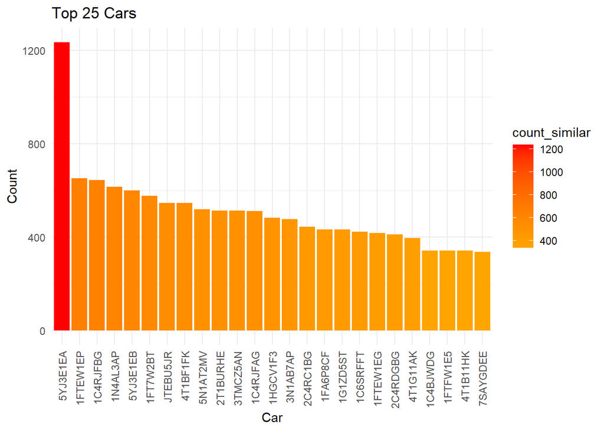

```r
plot0 <- vin2 |>
  slice_head(n = 25) |>
  ggplot(aes(x = reorder(car, -count_similar),
             y = count_similar,
             fill = count_similar)) +
  geom_bar(stat = "identity") +
  scale_fill_gradient(low = 'orange', high = 'red') +
  labs(x = 'Car', y = 'Count', title = 'Top 25 Cars') +
  theme_minimal() +
  theme(axis.text.x = element_text(angle = 90, vjust = 0.5, hjust = 1))

plot0
```

Great! Now it is apparent which type of vehicles are most commonly searched. The top vin relates to a tesla.

# Lets do the same but for more specific details

## Top 100 vehicle make (vin 1-3)

```r
vin3 <- vin_grouped |>
  mutate(
    make = substr(vin, 1,3),
    ) |>
  select(-vin_count) |>
  group_by(make) |>
  summarise(make_count = n()) |>
  arrange(desc(make_count))

head(vin3)
```

```
## # A tibble: 6 × 2
##   make  make_count
##   <chr>      <int>
## 1 1FT         8425
## 2 1C4         8323
## 3 1FM         6281
## 4 1G1         4691
## 5 1C6         4026
## 6 1GC         3809
```

```r
make_frame <- vin3 |>
  slice_head(n = 100) |>
  mutate(category = case_when(
    row_number() <= 25 ~ 'Top 25 Vehicles By Make',
    (row_number() > 25 & row_number() <= 50) ~ '26 - 50 Vehicles By Make',
    (row_number() > 50 & row_number() <= 75) ~ '51 - 75 Vehicles By Make',
    row_number() > 75 ~ 'Last 25 Vehicles By Make'
  ))
```

```r
plot1 <- make_frame[1:25,] |>
  ggplot(aes(x = reorder(make, -make_count),
             y = make_count,
             fill = make_count)) +
  geom_bar(stat = 'identity') +
  scale_fill_gradient(low = 'lightblue', high = 'darkblue') +
  labs(x = 'Make', y = 'Count', title = 'Top 25 Vehicle Makes') +
  theme_minimal() +
  theme(axis.text.x = element_text(angle = 90, vjust = 0.5, hjust = 1))


plot2 <- make_frame[26:50,] |>
  ggplot(aes(x = reorder(make, -make_count),
             y = make_count,
             fill = make_count)) +
  geom_bar(stat = 'identity') +
  scale_fill_gradient(low = 'lightblue', high = 'darkblue') +
  labs(x = 'Make', y = 'Count', title = 'Vehicle Makes 26-50') +
  theme_minimal() +
  theme(axis.text.x = element_text(angle = 90, vjust = 0.5, hjust = 1))


plot3 <- make_frame[51:75,] |>
  ggplot(aes(x = reorder(make, -make_count),
             y = make_count,
             fill = make_count)) +
  geom_bar(stat = 'identity') +
  scale_fill_gradient(low = 'lightblue', high = 'darkblue') +
  labs(x = 'Make', y = 'Count', title = 'Vehicle Makes 51- 75') +
  theme_minimal() +
  theme(axis.text.x = element_text(angle = 90, vjust = 0.5, hjust = 1))


plot4 <- make_frame[75:100,] |>
  ggplot(aes(x = reorder(make, -make_count),
             y = make_count,
             fill = make_count)) +
  geom_bar(stat = 'identity') +
  scale_fill_gradient(low = 'lightblue', high = 'darkblue') +
  labs(x = 'Make', y = 'Count', title = 'Last 25 Vehicle Makes') +
  theme_minimal() +
  theme(axis.text.x = element_text(angle = 90, vjust = 0.5, hjust = 1))
```

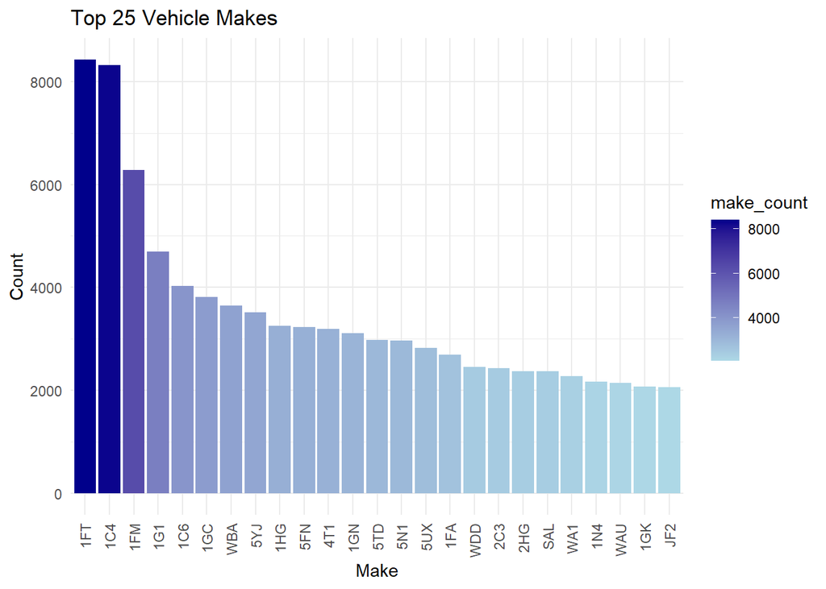

```r
plot1
```

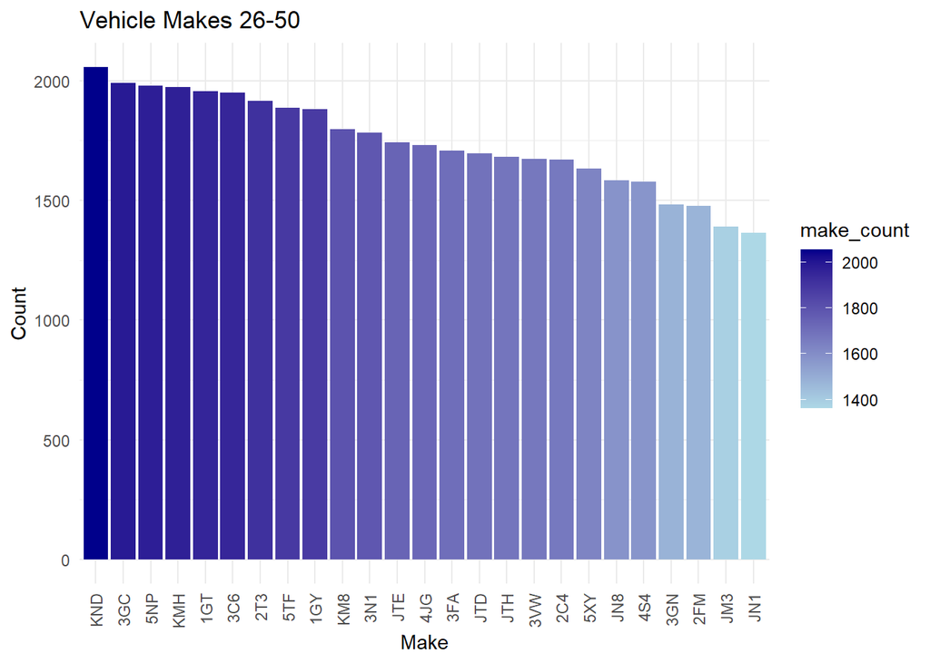

```r
plot2
```

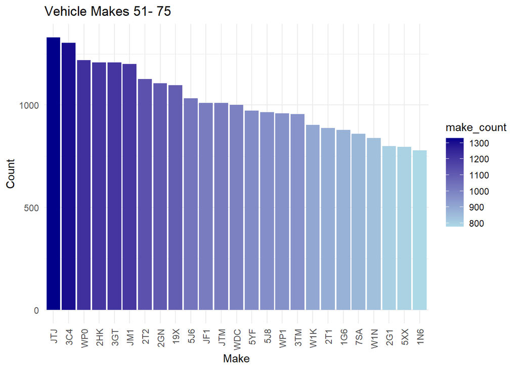

```r
plot3
```

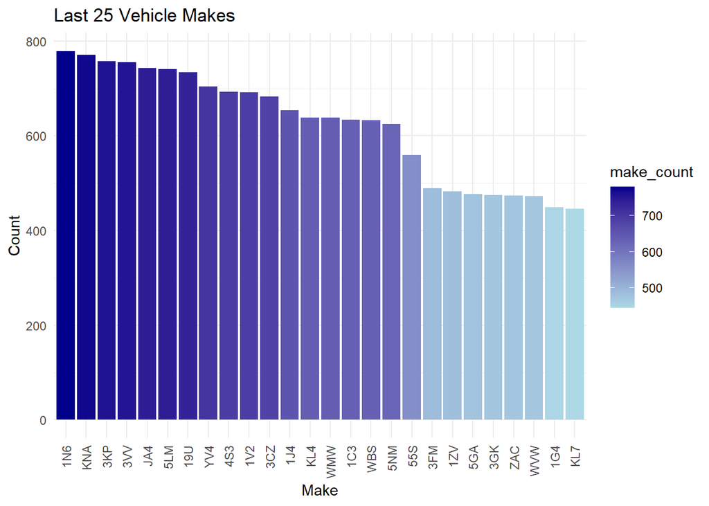

```r
plot4
```

# By description section

```r
descr_frame <- vin_grouped |>
  mutate(
    descr = substr(vin, 4,8)
    ) |>
  select(-vin_count) |>
  group_by(descr) |>
  summarise(descr_count = n()) |>
  arrange(desc(descr_count)) |>
  slice_head(n = 100) |>
  mutate(category = case_when(
    row_number() <= 25 ~ 'Top 25 Vehicles By descr',
    (row_number() > 25 & row_number() <= 50) ~ '26 - 50 Vehicles By descr',
    (row_number() > 50 & row_number() <= 75) ~ '51 - 75 Vehicles By descr',
    row_number() > 75 ~ 'Last 25 Vehicles By descr'
  ))

head(descr_frame)
```

```
## # A tibble: 6 × 3
##   descr descr_count category
##   <chr>       <int> <chr>
## 1 3E1EA        1235 Top 25 Vehicles By descr
## 2 AT2MV         832 Top 25 Vehicles By descr
## 3 CZ5AN         811 Top 25 Vehicles By descr
## 4 BURHE         759 Top 25 Vehicles By descr
## 5 BF1FK         658 Top 25 Vehicles By descr
## 6 EW1EP         653 Top 25 Vehicles By descr
```

```r
descr_plot1 <- descr_frame[1:25,] |>
  ggplot(aes(x = reorder(descr, -descr_count),
             y = descr_count,
             fill = descr_count)) +
  geom_bar(stat = 'identity') +
  scale_fill_gradient(low = 'purple', high = 'blue') +
  labs(x = 'descr', y = 'Count', title = 'Top 25 Vehicle Descriptions') +
  theme_minimal() +
  theme(axis.text.x = element_text(angle = 90, vjust = 0.5, hjust = 1))


descr_plot2 <- descr_frame[26:50,] |>
  ggplot(aes(x = reorder(descr, -descr_count),
             y = descr_count,
             fill = descr_count)) +
  geom_bar(stat = 'identity') +
  scale_fill_gradient(low = 'purple', high = 'blue') +
  labs(x = 'descr', y = 'Count', title = 'Vehicle Descriptions 26-50') +
  theme_minimal() +
  theme(axis.text.x = element_text(angle = 90, vjust = 0.5, hjust = 1))


descr_plot3 <- descr_frame[51:75,] |>
  ggplot(aes(x = reorder(descr, -descr_count),
             y = descr_count,
             fill = descr_count)) +
  geom_bar(stat = 'identity') +
  scale_fill_gradient(low = 'purple', high = 'blue') +
  labs(x = 'Descr', y = 'Count', title = 'Vehicle Descriptions 51- 75') +
  theme_minimal() +
  theme(axis.text.x = element_text(angle = 90, vjust = 0.5, hjust = 1))


descr_plot4 <- descr_frame[75:100,] |>
  ggplot(aes(x = reorder(descr, -descr_count),
             y = descr_count,
             fill = descr_count)) +
  geom_bar(stat = 'identity') +
  scale_fill_gradient(low = 'purple', high = 'blue') +
  labs(x = 'Descr', y = 'Count', title = 'Last 25 Vehicle Descriptions') +
  theme_minimal() +
  theme(axis.text.x = element_text(angle = 90, vjust = 0.5, hjust = 1))
```

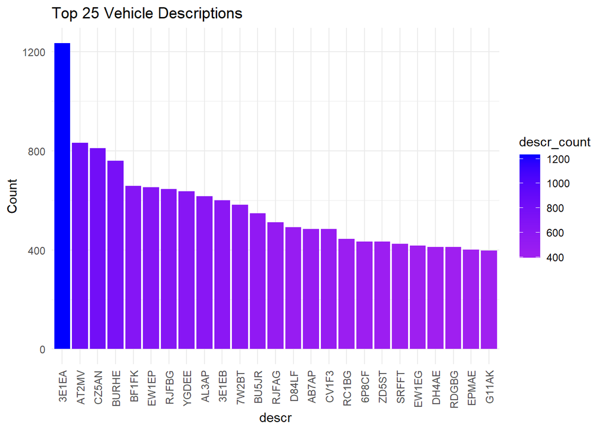

```r
descr_plot1
```

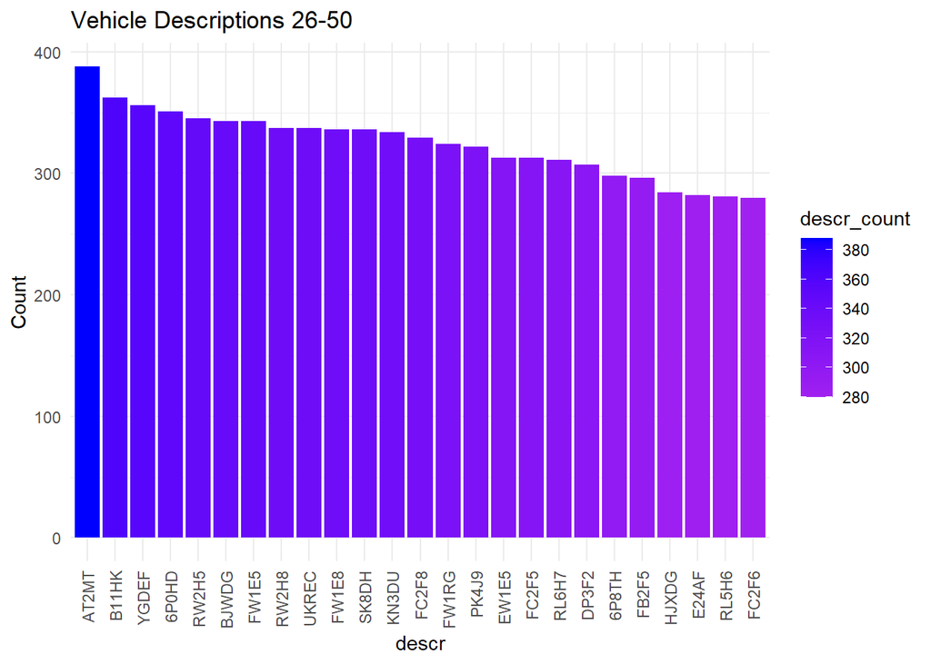

```r
descr_plot2
```

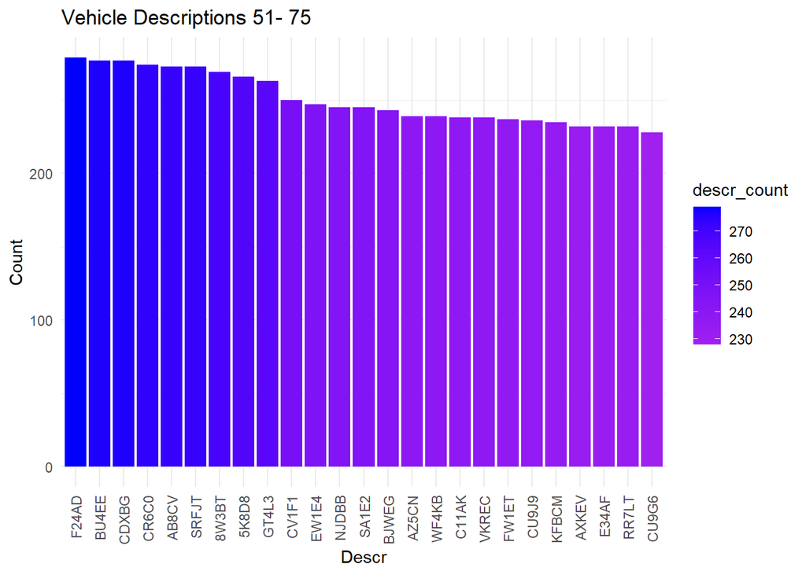

```r
descr_plot3
```

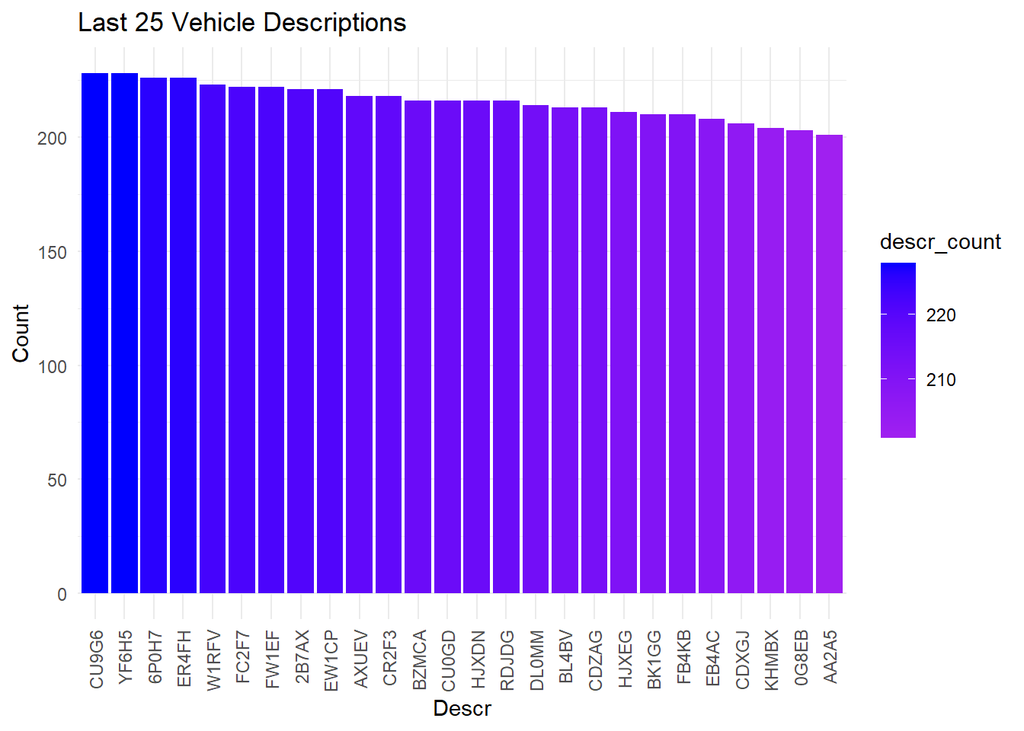

```r
descr_plot4
```

# By year

```r
year_frame <- vin_grouped |>
  mutate(year = substr(vin, 10, 10)) |>
  select(-vin_count) |>
  group_by(year) |>
  summarise(year_count = n()) |>
  arrange(desc(year_count)) |>
  slice_head(n = 100)

dim(year_frame)
```

```
## [1] 45  2
```

There are 45 total year counts from from sept. 1 - sept. 18. There is no need to random sample from the dataset, when grouped by year. A visual of top years follows.

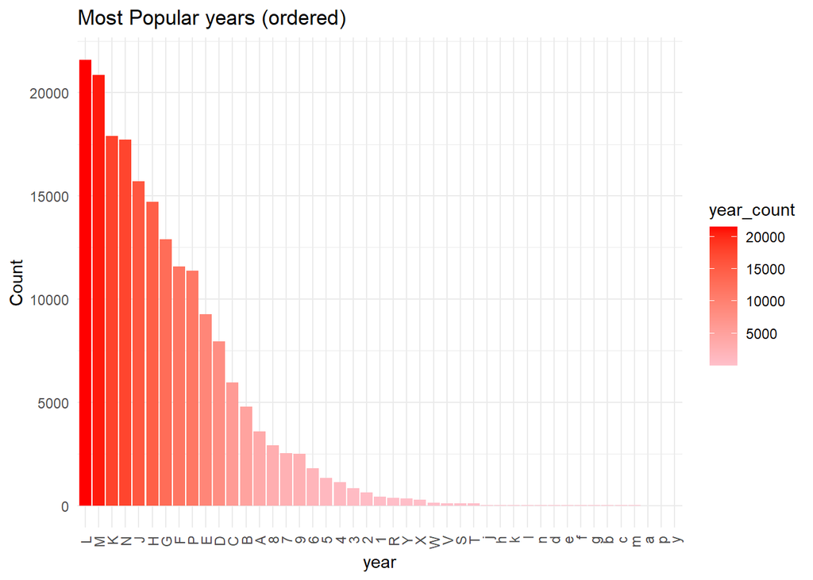

```r
plot5 <- year_frame |>
  ggplot(aes(x = reorder(year, -year_count),
             y = year_count,
             fill = year_count)) +
  geom_bar(stat = 'identity') +
  scale_fill_gradient(low = 'pink', high = 'red') +
  labs(x = 'year', y = 'Count', title = 'Most Popular years (ordered)') +
  theme_minimal() +
  theme(axis.text.x = element_text(angle = 90, vjust = 0.5, hjust = 1))
plot5
```

Since there is a vast difference between most common and least. I will spilt to help visualize years.

```r
plot6 <- year_frame[1:10,] |>
  ggplot(aes(x = reorder(year, -year_count),
             y = year_count,
             fill = year_count)) +
  geom_bar(stat = 'identity') +
  scale_fill_gradient(low = 'pink', high = 'red') +
  labs(x = 'year', y = 'Count', title = 'Most Popular years (ordered)') +
  theme_minimal() +
  theme(axis.text.x = element_text(angle = 90, vjust = 0.5, hjust = 1))

plot7 <- year_frame[11:20,] |>
  ggplot(aes(x = reorder(year, -year_count),
             y = year_count,
             fill = year_count)) +
  geom_bar(stat = 'identity') +
  scale_fill_gradient(low = 'pink', high = 'red') +
  labs(x = 'year', y = 'Count', title = 'Most Popular years (ordered)') +
  theme_minimal() +
  theme(axis.text.x = element_text(angle = 90, vjust = 0.5, hjust = 1))

plot8 <- year_frame[21:30,] |>
  ggplot(aes(x = reorder(year, -year_count),
             y = year_count,
             fill = year_count)) +
  geom_bar(stat = 'identity') +
  scale_fill_gradient(low = 'pink', high = 'red') +
  labs(x = 'year', y = 'Count', title = 'Most Popular years (ordered)') +
  theme_minimal() +
  theme(axis.text.x = element_text(angle = 90, vjust = 0.5, hjust = 1))

plot9 <- year_frame[31:45,] |>
  ggplot(aes(x = reorder(year, -year_count),
             y = year_count,
             fill = year_count)) +
  geom_bar(stat = 'identity') +
  scale_fill_gradient(low = 'pink', high = 'red') +
  labs(x = 'year', y = 'Count', title = 'Most Popular years (ordered)') +
  theme_minimal() +
  theme(axis.text.x = element_text(angle = 90, vjust = 0.5, hjust = 1))
```

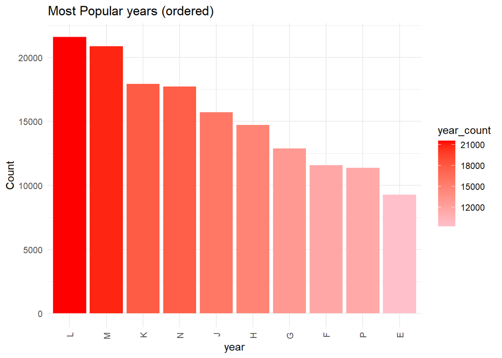

```r
plot6
```

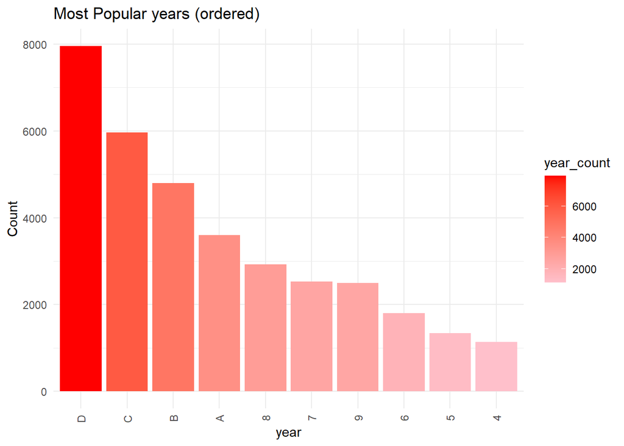

```r
plot7
```

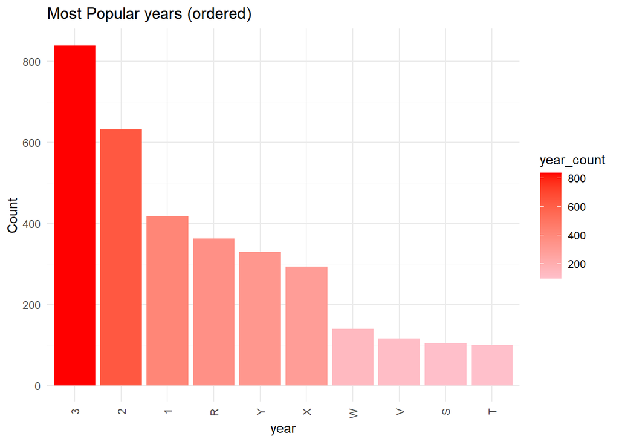

```r
plot8
```

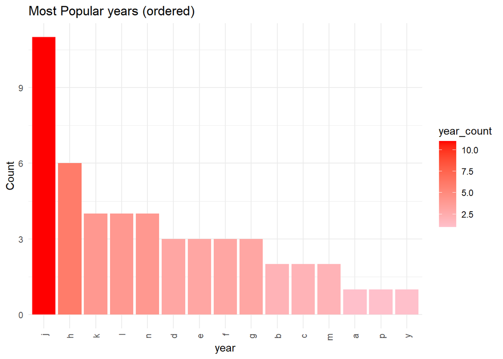

```r
plot9
```

# Output of top vehicles

The 25 most searched vehicles overall. This will include the whole vin.

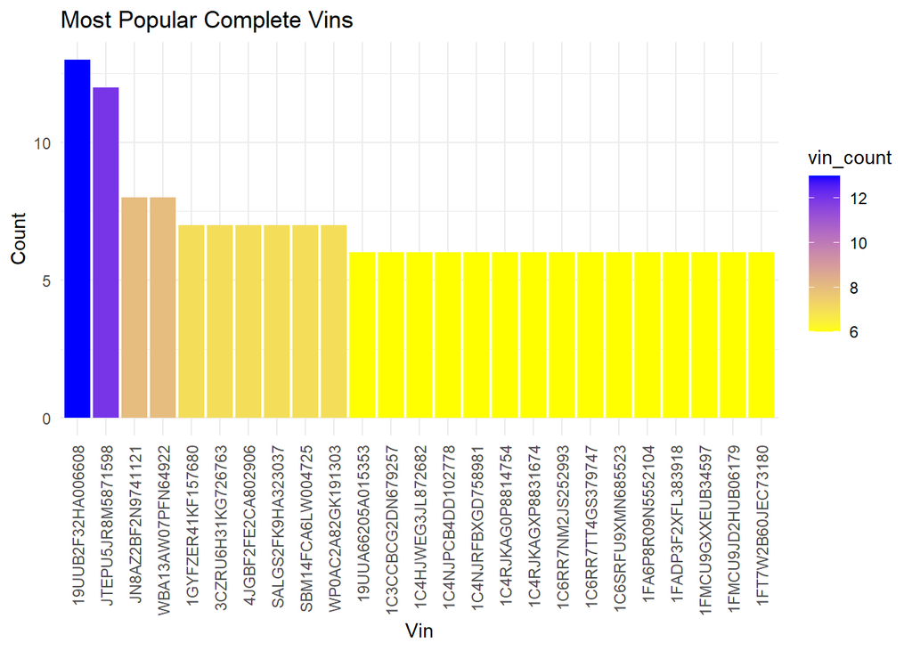

```r
plot10 <- vin_grouped |>
  slice_head(n = 25) |>
  ggplot(aes(x = reorder(vin, -vin_count),
             y = vin_count,
             fill = vin_count)) +
  geom_bar(stat = "identity") +
  scale_fill_gradient(low = 'yellow', high = 'blue') +
  labs(x = 'Vin', y = 'Count', title = 'Most Popular Complete Vins') +
  theme_minimal() +
  theme(axis.text.x = element_text(angle = 90, vjust = 0.5, hjust = 1))

plot10
```